# Bioconductor meetup November 20th: Creating a Bioconductor Package - Part 1.1

Shweta Gopaulakrishnan

11/10/2018

# Skeleton

- DESCRIPTION : To store important metadata about your package.
- NAMESPACE : Defines the functions, classes, and methods that are imported into the name space, and exported for users.
- NEWS : Keeps track of changes to the code from one version to the next.
- CITATION : Appropriate citations must be included in help pages and vignettes; this aspect of documentation is no different from any scientific endeavor.
- Including Data
- Package Documentation (vignettes, man pages)
- Unit Tests
- .gitignore : Bioconductor requires a git repository for submission.

## DESCRIPTION

- The job of the DESCRIPTION file is to store important metadata about your package

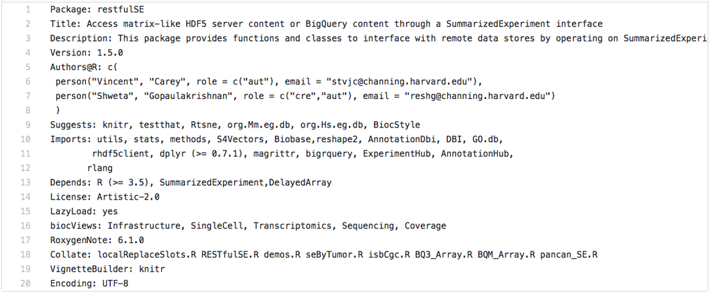

## NAMESPACE

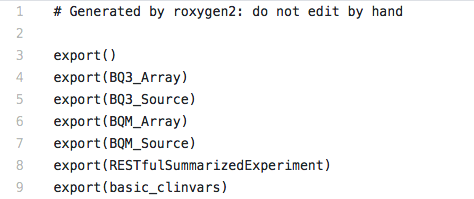

## NEWS

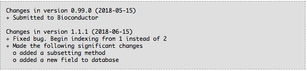

# Roxygen

## Why do we need documentation?

- Documentation is one of the most important aspects of a good package.
- Without it, users won’t know how to use your package.
- Documentation is also useful for future-you (so you remember what your functions were supposed to do), and for developers extending your package.

## How to use Roxygen ?

- Add roxygen comments to your .R files.
- Run devtools::document() (or roxygen2::roxygenise()) to convert roxygen comments to .Rd files. (devtools::document() calls roxygen2::roxygenise() to do the hard work.)
- Roxygen will also create a NAMESPACE for you, and will manage the Collate field in DESCRIPTION.

## Documenting Functions

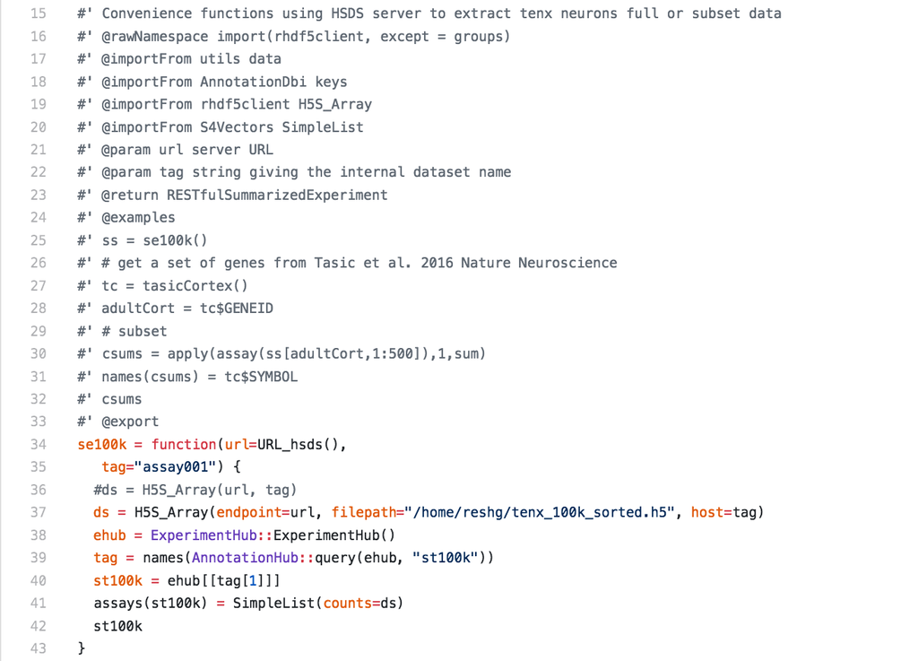

## Documenting datasets

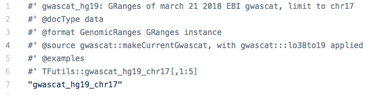

## Documenting classes, generics and methods

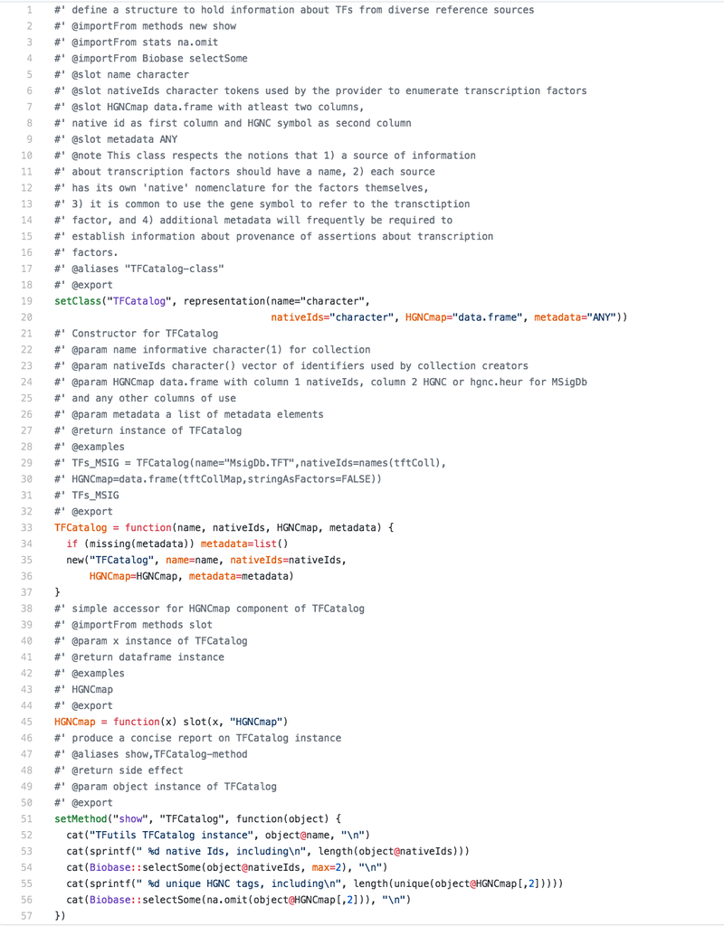

# Unit Tests

- Testing is a vital part of package development.
- It ensures that your code does what you want it to do.
- RUnit or testthat packages to write unit tests.

Guide : http://bioconductor.org/developers/how-to/unitTesting-guidelines/

## Example

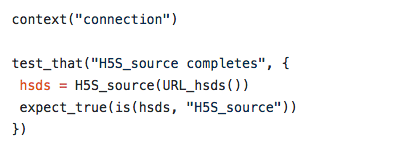

## Test Coverage

- Test coverage refers to the percentage of your package code that is tested by your unit tests.
- Packages with higher coverage have a lower chance of containing bugs.

# References

1. https://cran.r-project.org/web/packages/qwraps2/vignettes/create_pkg.html
2. http://r-pkgs.had.co.nz/
3. https://www.bioconductor.org/developers/package-guidelines/#unittest